# IODS course project

Kuunsäde Mäenpää

# Introduction to Open Data Science - Course Project

# Chapter 1 - Warmup

## Feelings and expectations

I’m quite excited to participate in this course. I’ve already used *R* and *R Markdown* before but I know my way of coding is not efficient or clean. This is why I expect to learn better methods to use *R*, *R Markdown* and other tools introduced during the next month or so.

My PhD supervisor told me about this course because she thought I could greatly benefit from this.

Just a sidenote about my name. I’ll sign with the names **Kuunsäde** or **Kuutis** because those are what I’m called nowadays. However, my legal name is Stina (but hopefully not for long). I hope this won’t confuse anyone!

## Link to GitHub repository

Just click the link below.

https://github.com/kuunsade/IODS-project

## Trying this for fun

```r
# I want to print out today's date

date()
```

```
## [1] "Thu Nov 26 14:58:33 2020"
```

I did it. Hooray!

## Creating a list

Let’s try this out.

- First point
- Second point
- Third point

# Chapter 2 - Data wrangling and analysis

## Introducing the data

First we read the students2014 data, which is provided in a website. After that, we look at what the data consist of.

```r
# Download the data

students2014 <- read.table("http://s3.amazonaws.com/assets.datacamp.com/production/course_2218/datasets/learning2014.txt ", sep=",", header=TRUE)

# First look at the data

head(students2014)
```

```
##   gender age attitude     deep  stra     surf points
## 1      F  53      3.7 3.583333 3.375 2.583333     25
## 2      M  55      3.1 2.916667 2.750 3.166667     12
## 3      F  49      2.5 3.500000 3.625 2.250000     24
## 4      M  53      3.5 3.500000 3.125 2.250000     10
## 5      M  49      3.7 3.666667 3.625 2.833333     22
## 6      F  38      3.8 4.750000 3.625 2.416667     21
```

```r
# Look at the dimensions and structures of the data

dim(students2014)
```

```
## [1] 166   7
```

```r
str(students2014)
```

```
## 'data.frame':    166 obs. of  7 variables:
##  $ gender  : Factor w/ 2 levels "F","M": 1 2 1 2 2 1 2 1 2 1 ...
##  $ age     : int  53 55 49 53 49 38 50 37 37 42 ...
##  $ attitude: num  3.7 3.1 2.5 3.5 3.7 3.8 3.5 2.9 3.8 2.1 ...
##  $ deep    : num  3.58 2.92 3.5 3.5 3.67 ...
##  $ stra    : num  3.38 2.75 3.62 3.12 3.62 ...
##  $ surf    : num  2.58 3.17 2.25 2.25 2.83 ...
##  $ points  : int  25 12 24 10 22 21 21 31 24 26 ...
```

So the data include:

- demographic information about students (age, gender)
- the student’s attitude score towards statistics based on a questionnare (attitude)
- student exam points (points)
- student scores on deep learning based on a questionnare (deep)
- student scores on strategic learning based on a questionnare (stra)
- student scores on surface-level learning based on a questionnare (surf)

The data frame has 166 observations (rows) and 7 variables (columns). When we take a look at the structure, most individual observations are numerical. Two columns include integers (age, points) and one includes factors (gender).

Let’s look at a summary of the observations.

```r
summary(students2014)
```

```
##  gender       age           attitude          deep            stra
##  F:110   Min.   :17.00   Min.   :1.400   Min.   :1.583   Min.   :1.250
##  M: 56   1st Qu.:21.00   1st Qu.:2.600   1st Qu.:3.333   1st Qu.:2.625
##          Median :22.00   Median :3.200   Median :3.667   Median :3.188
##          Mean   :25.51   Mean   :3.143   Mean   :3.680   Mean   :3.121
##          3rd Qu.:27.00   3rd Qu.:3.700   3rd Qu.:4.083   3rd Qu.:3.625
##          Max.   :55.00   Max.   :5.000   Max.   :4.917   Max.   :5.000
##       surf           points
##  Min.   :1.583   Min.   : 7.00
##  1st Qu.:2.417   1st Qu.:19.00
##  Median :2.833   Median :23.00
##  Mean   :2.787   Mean   :22.72
##  3rd Qu.:3.167   3rd Qu.:27.75
##  Max.   :4.333   Max.   :33.00
```

Most of the students are women and most students are in their 20s. The oldest student is 55 years old. Based on the summary, attitude, deep, strategic and surface scores have a scale from 1-5. The highest exam points has been 33 points, and most of the points were above 20.

## Graphical overview of the data

Let’s plot the whole dataset to get a general idea, how the data behave in pairs.

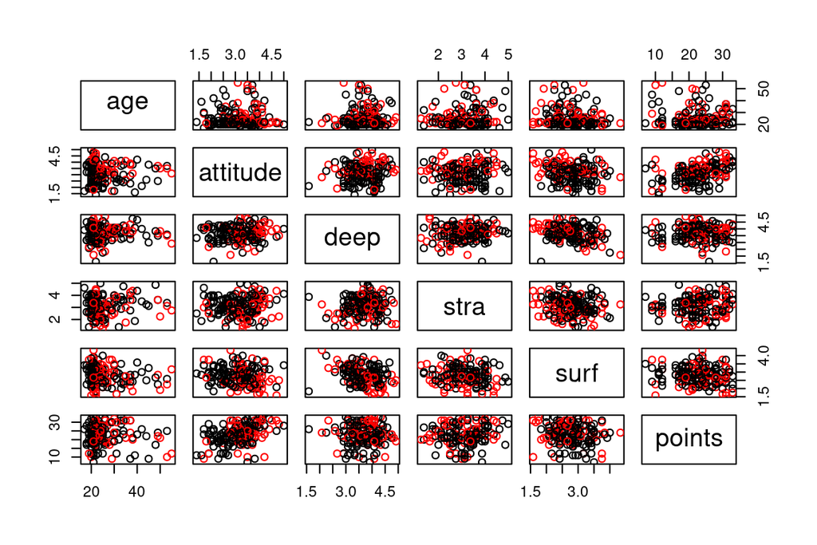

```r
plot(students2014[-1], col = students2014$gender)
```

We can use ggplot2 and GGally packages to generate a more advanced plot. Disregard the “upper” part inside the ggpairs command if you’re not using Linux. Otherwise FYI for Linux users: Ubuntu has some font issues with GGally and that part of the code is a workaround.

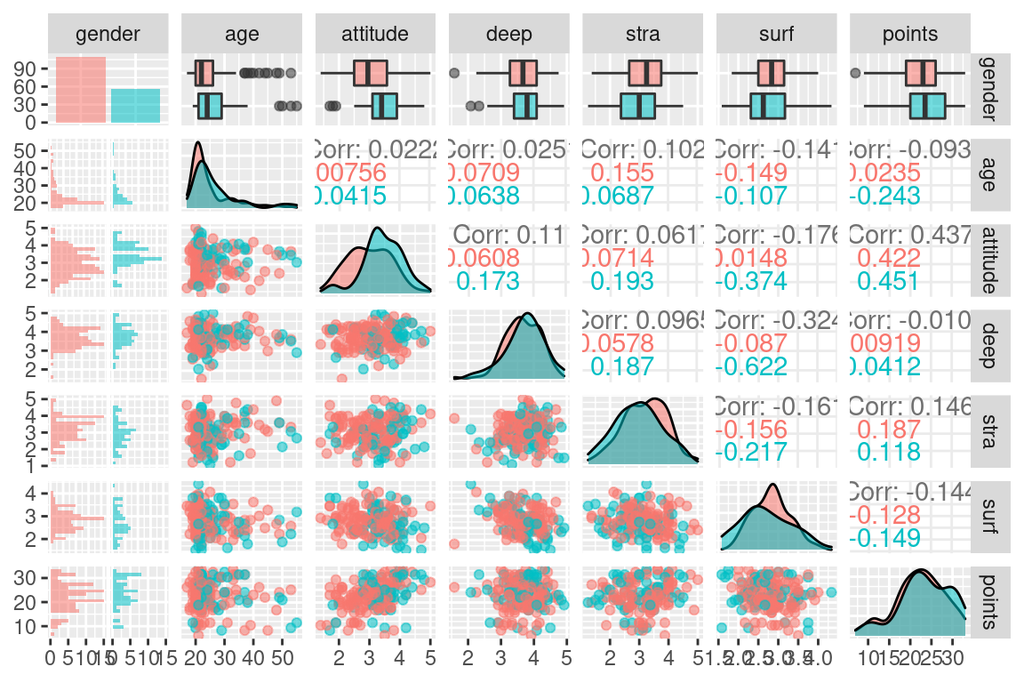

```r
library(ggplot2)
library(GGally)

plot <- ggpairs(students2014, mapping = aes(col=gender, alpha = 0.3), upper = list(continuous = "cor_v1_5"), lower = list(combo = wrap("facethist", bins = 20)))

plot
```

We get some additional information out of this plot. It is important to look at the correlation values (Corr). The higher the absolute value, the greater the correlation between the variables. We observe that points and attitude have a positive correlation value of 0.437, which is the highest in this dataset. Other correlations worth noting are strategic and surface, which both have approximately a 0.14 value. Surface scores correlate negatively with points since the value is negative.

## Regression model

Since attitude, surf and stra are most correlated with points, we’ll fit a linear model on these variables. Our variable of interest is points (y) and our explanatory variables (x1, x2, x3) are attitude, stra and surf.

```r
model <- lm(points ~ attitude + surf + stra, data = students2014)

summary(model)
```

```
##
## Call:
## lm(formula = points ~ attitude + surf + stra, data = students2014)
##
## Residuals:
##      Min       1Q   Median       3Q      Max
## -17.1550  -3.4346   0.5156   3.6401  10.8952
##
## Coefficients:
##             Estimate Std. Error t value Pr(>|t|)
## (Intercept)  11.0171     3.6837   2.991  0.00322 **
## attitude      3.3952     0.5741   5.913 1.93e-08 ***
## surf         -0.5861     0.8014  -0.731  0.46563
## stra          0.8531     0.5416   1.575  0.11716
## ---
## Signif. codes:  0 '***' 0.001 '**' 0.01 '*' 0.05 '.' 0.1 ' ' 1
##
## Residual standard error: 5.296 on 162 degrees of freedom
## Multiple R-squared:  0.2074, Adjusted R-squared:  0.1927
## F-statistic: 14.13 on 3 and 162 DF,  p-value: 3.156e-08
```

Considering explanatory variables, we see from the summary that only attitude has a significant correlation (p < 0.001) with points. Surf and stra don’t correlate significantly with points. We’ll run the model again with attitude only, since surf and stra were unnecessarily included.

```r
model <- lm(points ~ attitude, data = students2014)

summary(model)
```

```
##
## Call:
## lm(formula = points ~ attitude, data = students2014)
##
## Residuals:
##      Min       1Q   Median       3Q      Max
## -16.9763  -3.2119   0.4339   4.1534  10.6645
##
## Coefficients:
##             Estimate Std. Error t value Pr(>|t|)
## (Intercept)  11.6372     1.8303   6.358 1.95e-09 ***
## attitude      3.5255     0.5674   6.214 4.12e-09 ***
## ---
## Signif. codes:  0 '***' 0.001 '**' 0.01 '*' 0.05 '.' 0.1 ' ' 1
##
## Residual standard error: 5.32 on 164 degrees of freedom
## Multiple R-squared:  0.1906, Adjusted R-squared:  0.1856
## F-statistic: 38.61 on 1 and 164 DF,  p-value: 4.119e-09
```

The p value became slightly more significant compared to our previous model. Additionally, we observe that attitude has a positive correlation with points since the estimate value is greater than zero. The intercept refers to the point where the regression line intercepts with y axis, so when x (attitude) is zero, y (points) is 11.6372. The intercept value is statistically significant (p < 0.001).

## Model diagnostics

To confirm our model works for our data, we’ll run some diagnostics. Let’s generate the plots first.

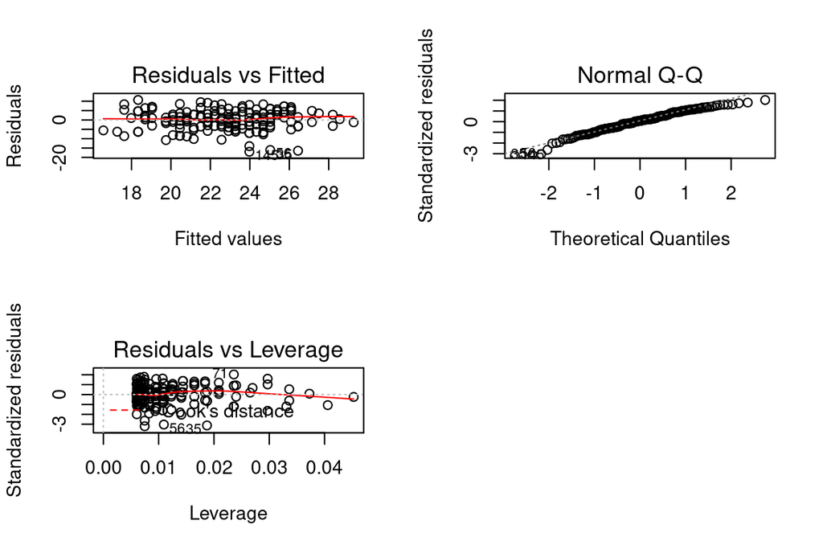

```r
par(mfrow = c(2,2))
plot(model, which = c(1,2,5))
```

Linear model assumes the residuals are normally distributed with a constant variance and that the residuals don’t correlate. From the Residuals vs. Fitted plot we observe that the data points vary in a quite random fashion. For example, if the data points were more close to each other on the left side but scattered on the right side, we would have a problem.

Q-Q plot can be used to confirm the normality assumption: the better the points fall on the line, the better the model fit. Some of the points in the beginning and end of the line stray, but overall the points follow our dashes quite nicely.

Residuals vs. Leverage is used for the dependacy assumption. We can to identify outliers if necessary. In our plot, there are no identifiable outliers, since the data points are fairly close to each other, which the x axis values confirm. If the x axis values were greater and there was a single point far away from the other data points, we would have to reconsider our model.

Overall, our diagnostics show that our linear model can be used to fit the data.

# Chapter 3 - Logistic regression

Let’s download the data we’re using for this exercise and explore the structure.

```r
student_alc <- read.table("pormath.txt")

dim(student_alc)
```

```
## [1] 370  51
```

```r
str(student_alc)
```

```
## 'data.frame':    370 obs. of  51 variables:
##  $ school    : Factor w/ 2 levels "GP","MS": 1 1 1 1 1 1 1 1 1 1 ...
##  $ sex       : Factor w/ 2 levels "F","M": 1 1 1 1 1 1 1 1 1 1 ...
##  $ age       : int  15 15 15 15 15 15 15 15 15 15 ...
##  $ address   : Factor w/ 2 levels "R","U": 1 1 1 1 1 1 1 1 1 2 ...
##  $ famsize   : Factor w/ 2 levels "GT3","LE3": 1 1 1 1 1 1 1 2 2 1 ...
##  $ Pstatus   : Factor w/ 2 levels "A","T": 2 2 2 2 2 2 2 2 2 1 ...
##  $ Medu      : int  1 1 2 2 3 3 3 2 3 3 ...
##  $ Fedu      : int  1 1 2 4 3 4 4 2 1 3 ...
##  $ Mjob      : Factor w/ 5 levels "at_home","health",..: 1 3 1 4 4 4 4 2 3 3 ...
##  $ Fjob      : Factor w/ 5 levels "at_home","health",..: 3 3 3 2 4 2 5 4 3 2 ...
##  $ reason    : Factor w/ 4 levels "course","home",..: 2 4 4 1 4 1 1 4 4 4 ...
##  $ guardian  : Factor w/ 3 levels "father","mother",..: 2 2 2 2 3 2 1 2 1 1 ...
##  $ traveltime: int  2 1 1 1 2 1 2 2 2 1 ...
##  $ studytime : int  4 2 1 3 3 3 3 2 4 4 ...
```

[output cut: 37 more lines]

```r
head(student_alc)
```

```
##   school sex age address famsize Pstatus Medu Fedu     Mjob     Fjob     reason
## 1     GP   F  15       R     GT3       T    1    1  at_home    other       home
## 2     GP   F  15       R     GT3       T    1    1    other    other reputation
## 3     GP   F  15       R     GT3       T    2    2  at_home    other reputation
## 4     GP   F  15       R     GT3       T    2    4 services   health     course
## 5     GP   F  15       R     GT3       T    3    3 services services reputation
## 6     GP   F  15       R     GT3       T    3    4 services   health     course
##   guardian traveltime studytime schoolsup famsup activities nursery higher
## 1   mother          2         4       yes    yes        yes     yes    yes
## 2   mother          1         2       yes    yes         no      no    yes
## 3   mother          1         1       yes    yes        yes     yes    yes
## 4   mother          1         3       yes    yes        yes     yes    yes
## 5    other          2         3        no    yes        yes     yes    yes
## 6   mother          1         3       yes    yes        yes     yes    yes
##   internet romantic famrel freetime goout Dalc Walc health n id.p id.m failures
```

[output cut: 20 more lines]

The dataset includes student performance information in secondary education of two Portuguese schools. We have 370 students (rows or observations) and 51 attributes (columns or variables). These 51 variables include sex, grades (G1, G2, G3), age, school, and information about the student’s social and family factors. Two distinct school subjects were of interest: math and Portuguese language.

More details about the dataset can be found here: https://archive.ics.uci.edu/ml/datasets/Student+Performance

## Overview of the data

In this exercise we want to explore the relationship between alcohol consumption and academic performance. The dataset was modified to inlcude alc_use and high_use, the first including average alcohol consumption during the week. The latter was constructed so that high alcohol use was set to be over 2. We are only including G3 grades, since this column includes final grades. Note that the data were wrangled with Reijo Sund’s code, so the dataset differs from the DataCamp set.

Let’s look at high_use, absences, study time, failures and if there are differences between men and women. I hypothesise high consumption results in lower grades, more absences, less study time and more failures. I also hypothesise there are differences between the sexes.

First we’ll cross-tabulate. I excluded absences from cross-tabulation since the results were hard to interpret.

```r
library(tidyr); library(dplyr); library(ggplot2)
student_alc %>% group_by(failures, high_use) %>% summarise(count = n(), mean_grade = mean(G3))
```

```
## # A tibble: 8 x 4
## # Groups:   failures [4]
##   failures high_use count mean_grade
##      <int> <lgl>    <int>      <dbl>
## 1        0 FALSE      238      12.2
## 2        0 TRUE        87      11.5
## 3        1 FALSE       12       8.08
## 4        1 TRUE        12       9.25
## 5        2 FALSE        8       7
## 6        2 TRUE         9       8.33
## 7        3 FALSE        1      10
## 8        3 TRUE         3       7.33
```

```r
student_alc %>% group_by(studytime, high_use) %>% summarise(count = n(), mean_grade = mean(G3))
```

```
## # A tibble: 8 x 4
## # Groups:   studytime [4]
##   studytime high_use count mean_grade
##       <int> <lgl>    <int>      <dbl>
## 1         1 FALSE       56       11
## 2         1 TRUE        42       10.4
## 3         2 FALSE      128       11.8
## 4         2 TRUE        57       10.8
## 5         3 FALSE       52       12.4
## 6         3 TRUE         8       13
## 7         4 FALSE       23       12.3
## 8         4 TRUE         4       12.5
```

```r
student_alc %>% group_by(sex, high_use) %>% summarise(count = n(), mean_grade = mean(G3))
```

```
## # A tibble: 4 x 4
## # Groups:   sex [2]
##   sex   high_use count mean_grade
##   <fct> <lgl>    <int>      <dbl>
## 1 F     FALSE      154       11.4
## 2 F     TRUE        41       11.8
## 3 M     FALSE      105       12.3
## 4 M     TRUE        70       10.3
```

We see that 0 failures are associated with lower alcohol consumption (high_use FALSE) and higher grades, while 0 failures and high alcohol consumption is associated with lower mean grade. The relationship is not as straightforward with more failures. Most of the student’s study time falls to category 2, where no alcohol is associated with better grades, but we also have a case of high alcohol consumption and higher study time (3-4) with slightly higher grades. Finally, men with high alcohol consumption seem to have lower grades.

Now for some plots, in which we separate by sex.

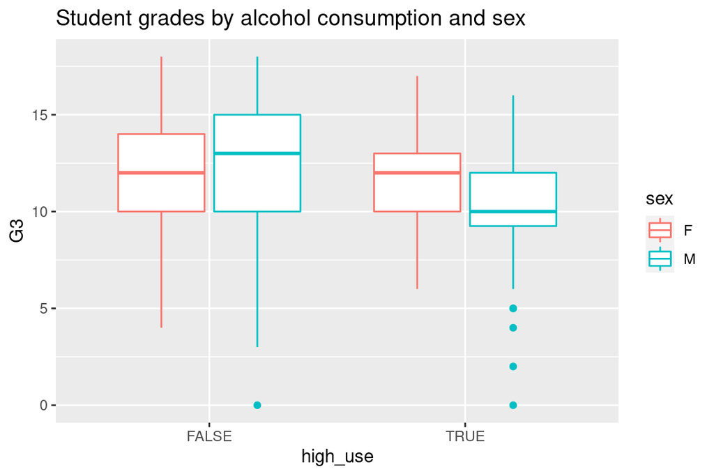

```r
ggplot(student_alc, aes(x = high_use, y = G3, col = sex))+ geom_boxplot() + ggtitle("Student grades by alcohol consumption and sex")
```

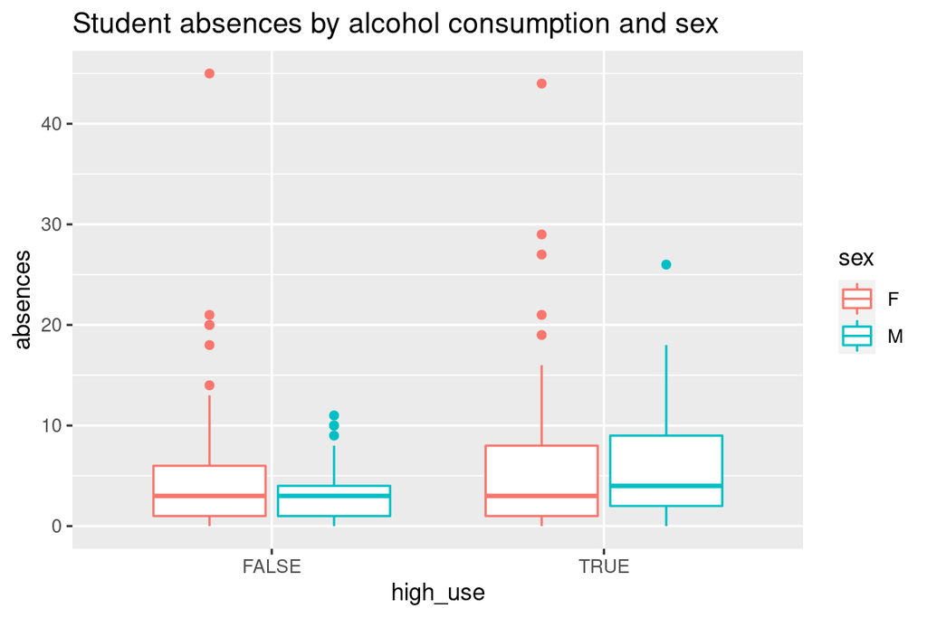

```r
ggplot(student_alc, aes(x = high_use, y = absences, col = sex))+ geom_boxplot() + ggtitle("Student absences by alcohol consumption and sex")
```

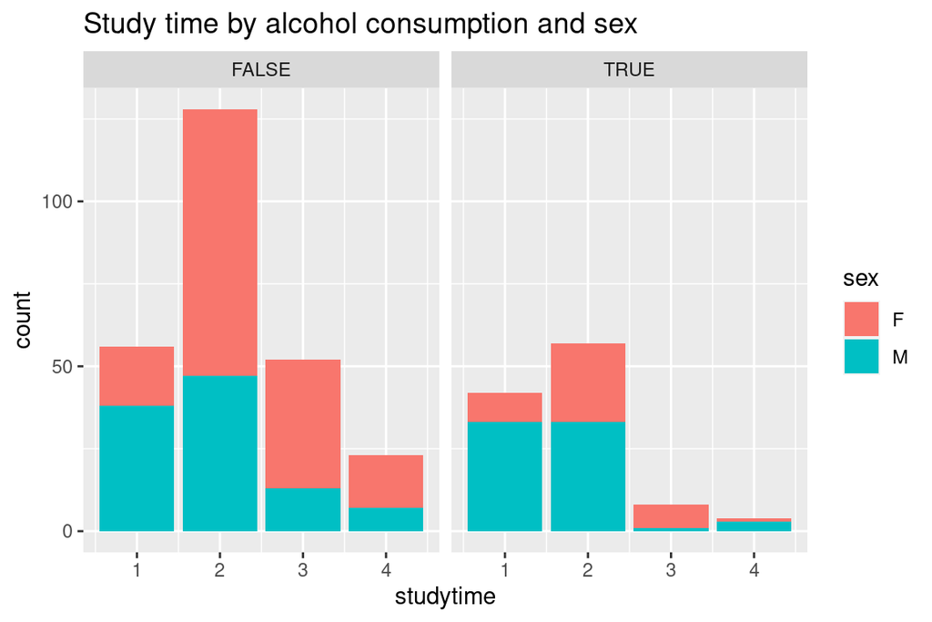

```r
ggplot(student_alc, aes(x=studytime, fill = sex)) + geom_bar() + ggtitle("Study time by alcohol consumption and sex") + facet_wrap(~high_use)
```

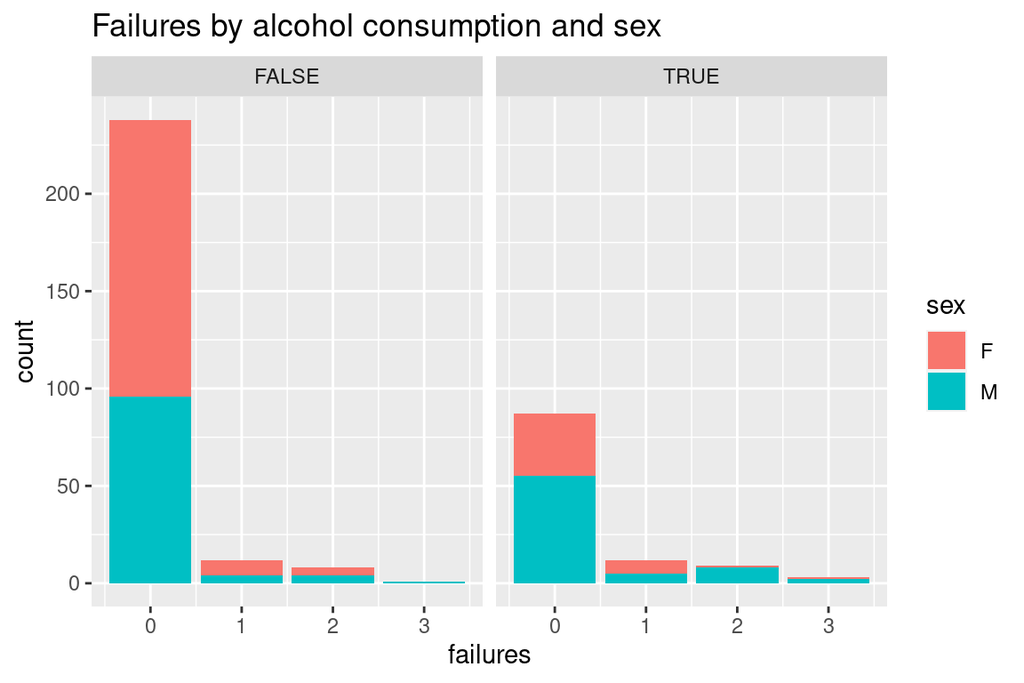

```r
ggplot(student_alc, aes(x=failures, fill = sex)) + geom_bar() + ggtitle("Failures by alcohol consumption and sex") + facet_wrap(~high_use)
```

From these plots we see that men’s grades are slightly lower when alcohol consumption is high. Absences seem to be slightly more common when alcohol consumption is high with both sexes. The relationship between consumption and study time is again not so straightforward. Failures on the other hand are more common in men when alcohol consumption is high. However, it’s good to bear in mind that the total number of high consumers is lower compared to low consumers of alcohol. My initial hypothesis was not too far off, but I’m surprised how different the results are between men and women.

## Logistic regression

We’ll run a generalised linear model with binomial distribution. We’ll explore the relationship of high alcohol use to the previously discussed variables failures, absences, sex, study time and final year grades (G3).

```r
# Generalised linear model
model <- glm(high_use ~ failures + absences + sex + studytime + G3, data = student_alc, family = "binomial")

# Summary of the model
summary(model)
```

```
##
## Call:
## glm(formula = high_use ~ failures + absences + sex + studytime +
##     G3, family = "binomial", data = student_alc)
##
## Deviance Residuals:
##     Min       1Q   Median       3Q      Max
## -2.0917  -0.8297  -0.5871   1.0191   2.1975
##
## Coefficients:
##             Estimate Std. Error z value Pr(>|z|)
## (Intercept) -0.72528    0.61497  -1.179 0.238246
## failures     0.43511    0.22355   1.946 0.051610 .
## absences     0.08514    0.02320   3.670 0.000242 ***
## sexM         0.86638    0.25849   3.352 0.000803 ***
## studytime   -0.32357    0.16400  -1.973 0.048505 *
## G3          -0.03905    0.04017  -0.972 0.330952
## ---
## Signif. codes:  0 '***' 0.001 '**' 0.01 '*' 0.05 '.' 0.1 ' ' 1
##
## (Dispersion parameter for binomial family taken to be 1)
##
##     Null deviance: 452.04  on 369  degrees of freedom
## Residual deviance: 401.52  on 364  degrees of freedom
## AIC: 413.52
##
## Number of Fisher Scoring iterations: 4
```

We see that high alcohol use is statistically significantly associated with absences and with men. We see men (“sexM”) in the coefficients because the model used women (“sexF”) as a baseline, so compared to the baseline, male students are significantly associated with high alcohol use. Study time has a weaker relationship with high alcohol use, failures even more so, but the relationship is there. However, grades have no statistical significance in the model, so we’ll rerun the model without grades.

```r
model <- glm(high_use ~ failures + absences + sex + studytime, data = student_alc, family = "binomial")
summary(model)
```

```
##
## Call:
## glm(formula = high_use ~ failures + absences + sex + studytime,
##     family = "binomial", data = student_alc)
##
## Deviance Residuals:
##     Min       1Q   Median       3Q      Max
## -2.0891  -0.8278  -0.5908   1.0193   2.1343
##
## Coefficients:
##             Estimate Std. Error z value Pr(>|z|)
## (Intercept) -1.15122    0.43431  -2.651 0.008033 **
## failures     0.50928    0.21127   2.411 0.015928 *
## absences     0.08650    0.02322   3.725 0.000195 ***
## sexM         0.84863    0.25759   3.295 0.000986 ***
## studytime   -0.33939    0.16338  -2.077 0.037771 *
## ---
## Signif. codes:  0 '***' 0.001 '**' 0.01 '*' 0.05 '.' 0.1 ' ' 1
##
## (Dispersion parameter for binomial family taken to be 1)
##
##     Null deviance: 452.04  on 369  degrees of freedom
## Residual deviance: 402.47  on 365  degrees of freedom
## AIC: 412.47
##
## Number of Fisher Scoring iterations: 4
```

```r
# Odds ratios (OR)
OR <- coef(model) %>% exp

# Confidence intervals (CI)
CI <- confint(model) %>% exp

# Print out the odds ratios with their confidence intervals
cbind(OR, CI)
```

```
##                    OR     2.5 %    97.5 %
## (Intercept) 0.3162522 0.1336630 0.7367549
## failures    1.6640983 1.1072255 2.5501879
## absences    1.0903516 1.0441945 1.1440122
## sexM        2.3364412 1.4162568 3.8963237
## studytime   0.7122080 0.5124273 0.9741384
```

Odds higher than 1 indicate that our explanatory variable has a positive association with our dependent variable (high_use). Therefore, men, absences and failures have a positive assocation but study time doesn’t. When we look at the confidence intervals, no interval contains the value 1, which indicates that their p value is lower than 0.05 and we can conclude the null hypothesis (variable has no relationship with high alcohol use) is false with 95 % certainty.

Based on these results, the hypothesis of high alcohol conspumtion resulting in lower grades, more absences, less study time and more failures is false when it comes to grades and study time. However, high consumption has a positive association with more absences and more failures. I also hypothesised there would be a difference between men and women, and this has proven to be correct. We’ll run the GLM model one more time to exclude study time, in order increase statiscial significance and predictive power of our model.

```r
model <- glm(high_use ~ failures + absences + sex, data = student_alc, family = "binomial")
summary(model)
```

```
##
## Call:
## glm(formula = high_use ~ failures + absences + sex, family = "binomial",
##     data = student_alc)
##
## Deviance Residuals:
##     Min       1Q   Median       3Q      Max
## -2.1550  -0.8430  -0.5889   1.0328   2.0374
##
## Coefficients:
##             Estimate Std. Error z value Pr(>|z|)
## (Intercept) -1.94150    0.23129  -8.394  < 2e-16 ***
## failures     0.59759    0.20698   2.887  0.00389 **
## absences     0.09245    0.02323   3.979 6.91e-05 ***
## sexM         0.99731    0.24725   4.034 5.49e-05 ***
## ---
## Signif. codes:  0 '***' 0.001 '**' 0.01 '*' 0.05 '.' 0.1 ' ' 1
##
## (Dispersion parameter for binomial family taken to be 1)
##
##     Null deviance: 452.04  on 369  degrees of freedom
## Residual deviance: 406.99  on 366  degrees of freedom
## AIC: 414.99
##
## Number of Fisher Scoring iterations: 4
```

```r
OR <- coef(model) %>% exp
CI <- confint(model) %>% exp
cbind(OR, CI)
```

```
##                    OR      2.5 %    97.5 %
## (Intercept) 0.1434892 0.08940913 0.2219242
## failures    1.8177381 1.21997630 2.7642305
## absences    1.0968598 1.05041937 1.1508026
## sexM        2.7109881 1.67967829 4.4367282
```

We see that the statistical significance of failures increased and the odds ratios of failures and sexM increased.

## Prediction and cross-validation

Let’s compute some predictions on our data.

```r
# Predict the probability of high_use
probabilities <- predict(model, type = "response")

# Add the predicted probabilities to student_alc
student_alc$probability <- probabilities

# Use the probabilities to make a prediction of high_use
student_alc <- mutate(student_alc, prediction = probability > 0.5)

# Tabulate the target variable versus the predictions
table(high_use = student_alc$high_use, prediction = student_alc$prediction)
```

```
##         prediction
## high_use FALSE TRUE
##    FALSE   252    7
##    TRUE     78   33
```

```r
# Tabulate the target variable versus the predictions
table(high_use = student_alc$high_use, prediction = student_alc$prediction) %>% prop.table %>% addmargins
```

```
##         prediction
## high_use      FALSE       TRUE        Sum
##    FALSE 0.68108108 0.01891892 0.70000000
##    TRUE  0.21081081 0.08918919 0.30000000
##    Sum   0.89189189 0.10810811 1.00000000
```

Our 2x2 table is a confusion matrix and it shows how well the predictions worked. The first table shows the actual numbers while the second shows prediction probabilites. In the first table, we see that when high_use is FALSE, the model predicted FALSE 252 times, which is correct, and TRUE 7 times, which is incorrect. However, according to the same table, the model was not good at predicting actual high_use, predicting actual TRUE 33 times and incorrect FALSE 78 times. The second table shows the same info with probabilites of the predictions and according to that table, actual FALSE predictions are correct most of the time (p = 0.68), while actual TRUE predictions didn’t perform too well (p = 0.089).

Let’s perform a 10-fold cross-validation.

```r
# Define a loss function (average prediction error)
loss_func <- function(class, prob) {
  n_wrong <- abs(class - prob) > 0.5
  mean(n_wrong)
}

# Compute the average number of wrong predictions in the (training) data
loss_func(student_alc$high_use, prob = student_alc$probability)
```

```
## [1] 0.2297297
```

```r
# K-fold cross-validation
library(boot)
cv <- cv.glm(data = student_alc, cost = loss_func, glmfit = model, K = 10)

# Average number of wrong predictions in the cross validation
cv$delta[1]
```

```
## [1] 0.2378378
```

The lower the average number of wrong predictions, the better. The training data had an average number of ~0.23 and our cross-validated data got an average number of 0.24. The cross-validated number which is slightly better than DataCamp’s 0.26 error. However, this can be due to different processing of the data, since the data wrangling process in DataCamp was not perfect and I used the corrected version by Reijo Sund.

# Chapter 4 - Clustering and classification

## Overview of the data

Let’s download the data for this exercise.

```r
library(MASS)
data("Boston")
```

The Boston dataset is titled “Housing Values in Suburbs of Boston” so the dataset includes information on variables which influence these values.

```r
library(dplyr)
glimpse(Boston)
```

```
## Rows: 506
## Columns: 14
## $ crim    <dbl> 0.00632, 0.02731, 0.02729, 0.03237, 0.06905, 0.02985, 0.08829…
## $ zn      <dbl> 18.0, 0.0, 0.0, 0.0, 0.0, 0.0, 12.5, 12.5, 12.5, 12.5, 12.5, …
## $ indus   <dbl> 2.31, 7.07, 7.07, 2.18, 2.18, 2.18, 7.87, 7.87, 7.87, 7.87, 7…
## $ chas    <int> 0, 0, 0, 0, 0, 0, 0, 0, 0, 0, 0, 0, 0, 0, 0, 0, 0, 0, 0, 0, 0…
## $ nox     <dbl> 0.538, 0.469, 0.469, 0.458, 0.458, 0.458, 0.524, 0.524, 0.524…
## $ rm      <dbl> 6.575, 6.421, 7.185, 6.998, 7.147, 6.430, 6.012, 6.172, 5.631…
## $ age     <dbl> 65.2, 78.9, 61.1, 45.8, 54.2, 58.7, 66.6, 96.1, 100.0, 85.9, …
## $ dis     <dbl> 4.0900, 4.9671, 4.9671, 6.0622, 6.0622, 6.0622, 5.5605, 5.950…
## $ rad     <int> 1, 2, 2, 3, 3, 3, 5, 5, 5, 5, 5, 5, 5, 4, 4, 4, 4, 4, 4, 4, 4…
## $ tax     <dbl> 296, 242, 242, 222, 222, 222, 311, 311, 311, 311, 311, 311, 3…
## $ ptratio <dbl> 15.3, 17.8, 17.8, 18.7, 18.7, 18.7, 15.2, 15.2, 15.2, 15.2, 1…
## $ black   <dbl> 396.90, 396.90, 392.83, 394.63, 396.90, 394.12, 395.60, 396.9…
## $ lstat   <dbl> 4.98, 9.14, 4.03, 2.94, 5.33, 5.21, 12.43, 19.15, 29.93, 17.1…
## $ medv    <dbl> 24.0, 21.6, 34.7, 33.4, 36.2, 28.7, 22.9, 27.1, 16.5, 18.9, 1…
```

The dataset has 14 columns and 506 observations. These columns include things like

- Crime rate (crim) per capita
- Proportion of residential land zoned (zn) for lots over 25,000 sq.ft. (whatever that converts to, Imperial units suck)
- Nitrogen oxides concentration (nx), parts per million
- Proportion of owner-occupied units built prior to 1940 (age)
- Weighed means of distances (dis) to five Boston employment centres
- Full-value propery-tax rate per $10,000 (tax)

And so on. Let’s look at some data summaries.

```r
library(ggplot2);library(GGally)
summary(Boston)
```

```
##       crim                zn             indus            chas
##  Min.   : 0.00632   Min.   :  0.00   Min.   : 0.46   Min.   :0.00000
##  1st Qu.: 0.08204   1st Qu.:  0.00   1st Qu.: 5.19   1st Qu.:0.00000
##  Median : 0.25651   Median :  0.00   Median : 9.69   Median :0.00000
##  Mean   : 3.61352   Mean   : 11.36   Mean   :11.14   Mean   :0.06917
##  3rd Qu.: 3.67708   3rd Qu.: 12.50   3rd Qu.:18.10   3rd Qu.:0.00000
##  Max.   :88.97620   Max.   :100.00   Max.   :27.74   Max.   :1.00000
##       nox               rm             age              dis
##  Min.   :0.3850   Min.   :3.561   Min.   :  2.90   Min.   : 1.130
##  1st Qu.:0.4490   1st Qu.:5.886   1st Qu.: 45.02   1st Qu.: 2.100
##  Median :0.5380   Median :6.208   Median : 77.50   Median : 3.207
##  Mean   :0.5547   Mean   :6.285   Mean   : 68.57   Mean   : 3.795
##  3rd Qu.:0.6240   3rd Qu.:6.623   3rd Qu.: 94.08   3rd Qu.: 5.188
##  Max.   :0.8710   Max.   :8.780   Max.   :100.00   Max.   :12.127
##       rad              tax           ptratio          black
##  Min.   : 1.000   Min.   :187.0   Min.   :12.60   Min.   :  0.32
##  1st Qu.: 4.000   1st Qu.:279.0   1st Qu.:17.40   1st Qu.:375.38
##  Median : 5.000   Median :330.0   Median :19.05   Median :391.44
##  Mean   : 9.549   Mean   :408.2   Mean   :18.46   Mean   :356.67
##  3rd Qu.:24.000   3rd Qu.:666.0   3rd Qu.:20.20   3rd Qu.:396.23
##  Max.   :24.000   Max.   :711.0   Max.   :22.00   Max.   :396.90
##      lstat            medv
##  Min.   : 1.73   Min.   : 5.00
##  1st Qu.: 6.95   1st Qu.:17.02
##  Median :11.36   Median :21.20
##  Mean   :12.65   Mean   :22.53
##  3rd Qu.:16.95   3rd Qu.:25.00
##  Max.   :37.97   Max.   :50.00
```

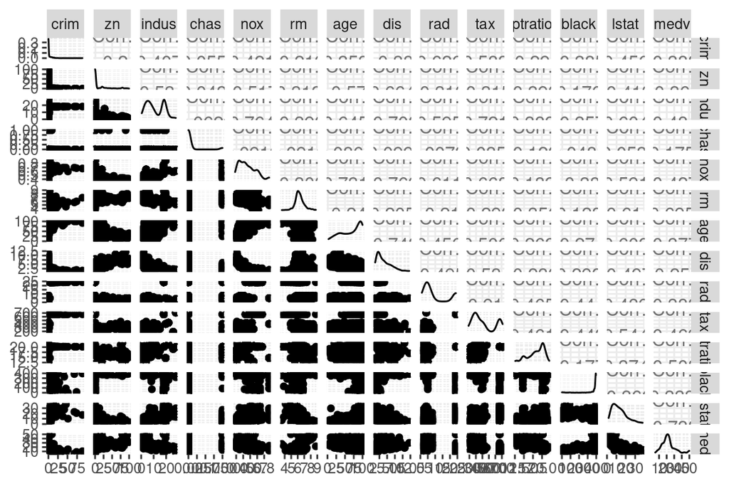

```r
ggpairs(Boston, upper = list(continuous = "cor_v1_5"))
```

## Scaling the data

We’ll scale the data by subtracting the column means from the corresponding columns and divide the difference with standard deviation. It’s simple to perform with the scale function.

```r
Boston_scaled <- scale(Boston)

# New summaries of the data after converting to data frame
Boston_scaled <- as.data.frame(Boston_scaled)
summary(Boston_scaled)
```

```
##       crim                 zn               indus              chas
##  Min.   :-0.419367   Min.   :-0.48724   Min.   :-1.5563   Min.   :-0.2723
##  1st Qu.:-0.410563   1st Qu.:-0.48724   1st Qu.:-0.8668   1st Qu.:-0.2723
##  Median :-0.390280   Median :-0.48724   Median :-0.2109   Median :-0.2723
##  Mean   : 0.000000   Mean   : 0.00000   Mean   : 0.0000   Mean   : 0.0000
##  3rd Qu.: 0.007389   3rd Qu.: 0.04872   3rd Qu.: 1.0150   3rd Qu.:-0.2723
##  Max.   : 9.924110   Max.   : 3.80047   Max.   : 2.4202   Max.   : 3.6648
##       nox                rm               age               dis
##  Min.   :-1.4644   Min.   :-3.8764   Min.   :-2.3331   Min.   :-1.2658
##  1st Qu.:-0.9121   1st Qu.:-0.5681   1st Qu.:-0.8366   1st Qu.:-0.8049
##  Median :-0.1441   Median :-0.1084   Median : 0.3171   Median :-0.2790
##  Mean   : 0.0000   Mean   : 0.0000   Mean   : 0.0000   Mean   : 0.0000
##  3rd Qu.: 0.5981   3rd Qu.: 0.4823   3rd Qu.: 0.9059   3rd Qu.: 0.6617
##  Max.   : 2.7296   Max.   : 3.5515   Max.   : 1.1164   Max.   : 3.9566
##       rad               tax             ptratio            black
##  Min.   :-0.9819   Min.   :-1.3127   Min.   :-2.7047   Min.   :-3.9033
##  1st Qu.:-0.6373   1st Qu.:-0.7668   1st Qu.:-0.4876   1st Qu.: 0.2049
##  Median :-0.5225   Median :-0.4642   Median : 0.2746   Median : 0.3808
##  Mean   : 0.0000   Mean   : 0.0000   Mean   : 0.0000   Mean   : 0.0000
##  3rd Qu.: 1.6596   3rd Qu.: 1.5294   3rd Qu.: 0.8058   3rd Qu.: 0.4332
##  Max.   : 1.6596   Max.   : 1.7964   Max.   : 1.6372   Max.   : 0.4406
##      lstat              medv
##  Min.   :-1.5296   Min.   :-1.9063
##  1st Qu.:-0.7986   1st Qu.:-0.5989
##  Median :-0.1811   Median :-0.1449
##  Mean   : 0.0000   Mean   : 0.0000
##  3rd Qu.: 0.6024   3rd Qu.: 0.2683
##  Max.   : 3.5453   Max.   : 2.9865
```

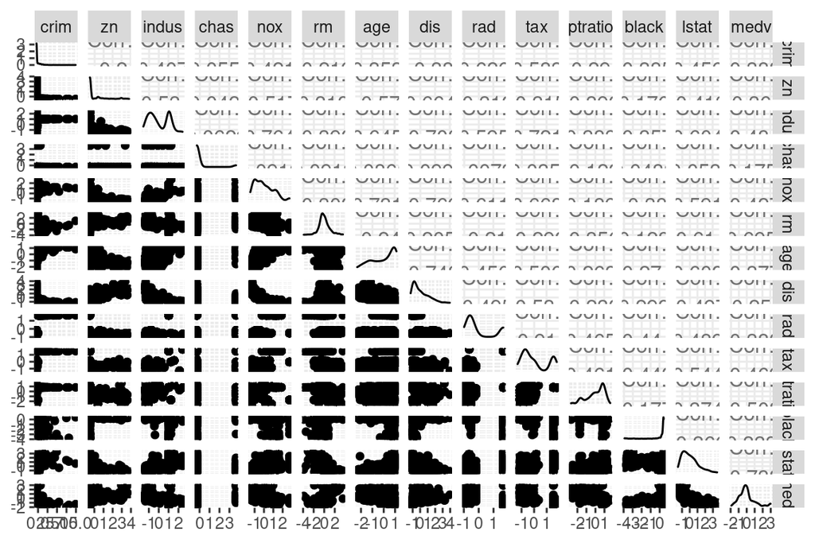

```r
ggpairs(Boston_scaled, upper = list(continuous = "cor_v1_5"))
```

The distributions didn’t change but scaling changed the units. Next we’ll create a categorical variable of crime rate.

```r
# Creating a quantile vector
quantiles <- quantile(Boston_scaled$crim)

# Creating the categorical variable
crime <- cut(Boston_scaled$crim, breaks = quantiles, include.lowest = TRUE, label = c("low", "med_low", "med_high", "high"))
table(crime)
```

```
## crime
##      low  med_low med_high     high
##      127      126      126      127
```

Looks good. We’ll add this new crime variable to the dataset and remove the old one.

```r
# Remove crim from the dataset
Boston_scaled <- dplyr::select(Boston_scaled, -crim)

# Add crime
Boston_scaled <- data.frame(Boston_scaled, crime)
```

Next we’ll create a test and training set. We’ll choose 80 % of the data for the training set, so that the remaining 20 % fall to the test set.

```r
# Randomly choose 80% of the scaled Boston rows
ind <- sample(nrow(Boston_scaled),  size = nrow(Boston_scaled) * 0.8)

# Create a training set
train <- Boston_scaled[ind,]

# Create a test set
test <- Boston_scaled[-ind,]
```

## Linear discriminant analysis

We’ll fit a linear discriminant analysis on the training set. For the sake of simplicity, we’ll run with two dimensions.

```r
lda_model <- lda(crime ~ ., data = train)
lda_model
```

```
## Call:
## lda(crime ~ ., data = train)
##
## Prior probabilities of groups:
##       low   med_low  med_high      high
## 0.2376238 0.2648515 0.2450495 0.2524752
##
## Group means:
##                   zn      indus        chas        nox         rm        age
## low       0.99805062 -0.8967905 -0.06727176 -0.8782722  0.3895421 -0.9236573
## med_low  -0.05626486 -0.2821376 -0.01476176 -0.5433922 -0.1484421 -0.3541633
## med_high -0.37290116  0.1133565  0.32420127  0.4000378  0.2216848  0.3327134
## high     -0.48724019  1.0171096 -0.15653200  1.0284767 -0.3784688  0.7994473
##                 dis        rad        tax     ptratio       black       lstat
## low       0.9082575 -0.6935581 -0.7103880 -0.42260121  0.37656177 -0.76054296
## med_low   0.3420385 -0.5375111 -0.4713666 -0.06277637  0.31547655 -0.14011080
## med_high -0.3492194 -0.3879165 -0.3221110 -0.39050987  0.06521004 -0.09094262
## high     -0.8443798  1.6382099  1.5141140  0.78087177 -0.84779818  0.87150984
##                  medv
## low       0.469068158
## med_low  -0.005396128
## med_high  0.290333126
## high     -0.720224837
##
## Coefficients of linear discriminants:
##                 LD1         LD2         LD3
## zn       0.13760274  0.75169856 -0.88240327
## indus    0.01997844 -0.10776897  0.47235874
## chas    -0.09112384 -0.10023298 -0.01698824
## nox      0.40531839 -0.82964869 -1.33279759
## rm      -0.09571192 -0.12502099 -0.23634630
## age      0.21328835 -0.29068008 -0.01308807
## dis     -0.11414021 -0.31711480  0.14616342
## rad      3.24777815  0.75570291 -0.09768309
## tax     -0.05216493  0.04180082  0.33374513
## ptratio  0.14584161  0.03037769 -0.26919591
## black   -0.12079870  0.02171585  0.13034215
## lstat    0.23408766 -0.21505583  0.34328869
## medv     0.21835943 -0.48323980 -0.21267759
##
## Proportion of trace:
##    LD1    LD2    LD3
## 0.9510 0.0362 0.0128
```

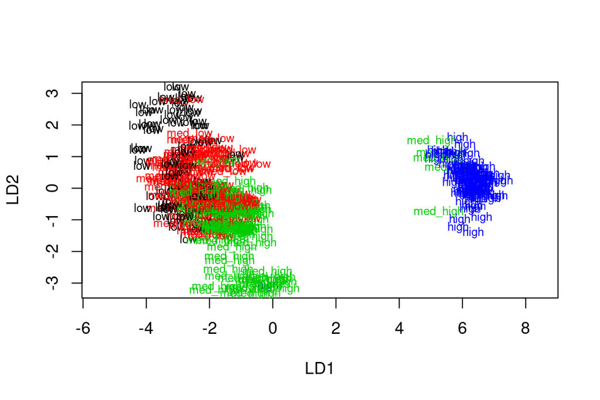

```r
plot(lda_model, dimen = 2, col = as.numeric(train$crime), pch = as.numeric(train$crime))
```

We’ll run a prediction model with LDA. Before that, the crime classes will be removed from the test set.

```r
# Save the correct classes from test data
correct_classes <- test$crime

# Remove the crime variable from test data
test <- dplyr::select(test, -crime)

# Predict with LDA
lda_predict <- predict(lda_model, newdata = test)
table(correct = correct_classes, predicted = lda_predict$class)
```

```
##           predicted
## correct    low med_low med_high high
##   low       17      13        1    0
##   med_low    0      18        1    0
##   med_high   0      14       12    1
##   high       0       0        0   25
```

## K-means algorithm

Next we’ll calculate distances between the observations. The dataset needs to be reloaded, after which we’ll scale the data and then calculate the distances.

```r
data("Boston")
Boston_rescaled <- scale(Boston)

# Euclidian distances
euc_Boston <- dist(Boston_rescaled)
#Manhattan distances
man_Boston <- dist(Boston_rescaled, method = "manhattan")

summary(euc_Boston)
```

```
##    Min. 1st Qu.  Median    Mean 3rd Qu.    Max.
##  0.1343  3.4625  4.8241  4.9111  6.1863 14.3970
```

```r
summary(man_Boston)
```

```
##    Min. 1st Qu.  Median    Mean 3rd Qu.    Max.
##  0.2662  8.4832 12.6090 13.5488 17.7568 48.8618
```

Manhattan distances tend to have higher units compared to Euclidian distances.

Next we’ll run K-means clustering and try to determine what is the best amount of centers for our data.

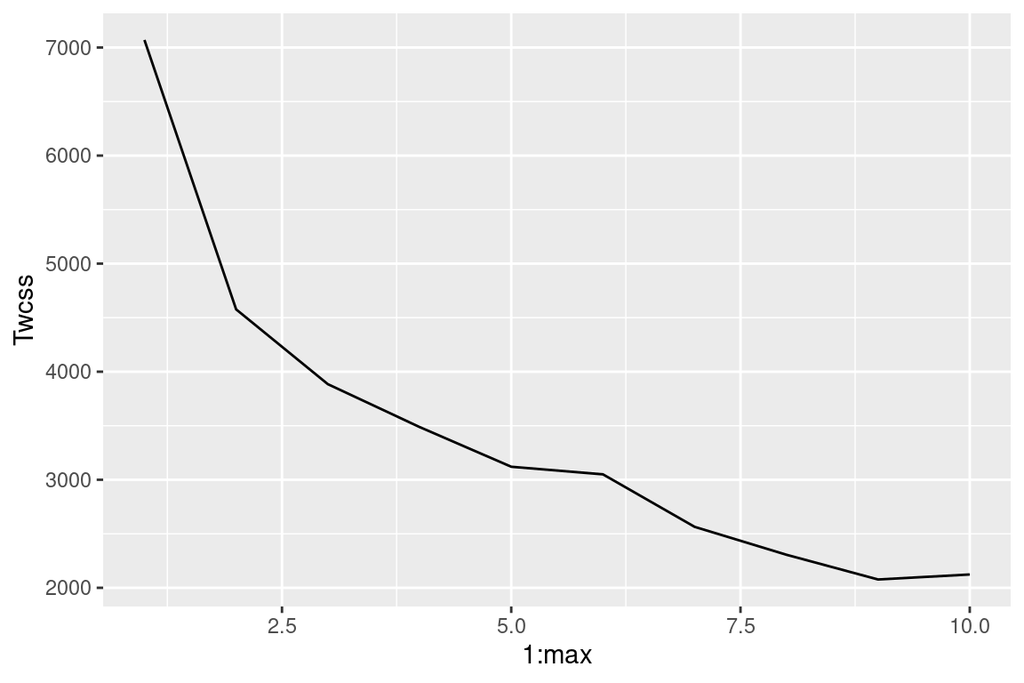

```r
# Define a maximum and calculate the total within sum of squares
max <- 10
Twcss <- sapply(1:max, function(k){kmeans(Boston_rescaled, k)$tot.withinss})

# Visualise
qplot(x = 1:max, y = Twcss, geom = 'line')
```

There’s a radical drop in the within cluster sum of squares at about point 2. We’ll use this as an optimal number of clusters.

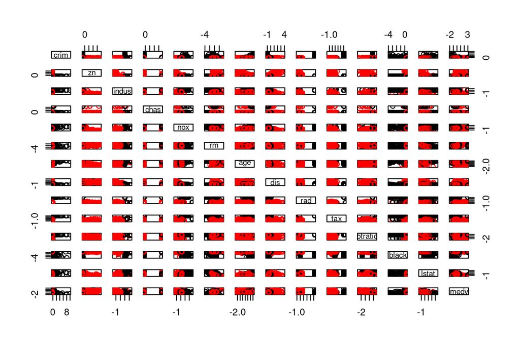

```r
# K-means clustering
km <- kmeans(Boston_rescaled, centers = 2)

# Plot the Boston dataset with clusters
pairs(Boston_rescaled, col = km$cluster)
```

Based on this, the two cluster optimum didn’t come out of nowhere. The two clusters seem to fall into their own groups in many cases like with variables crime, indus, nox, black, lstat, dis. One notable excpetion is the variable chas (Charles River dummy varaible) where the points are mixed when paired with e.g. age and pupil-teacher ratio (ptratio). We can’t, however, infer *what* exactly creates the dissimilarity. That’s a whole other exercise.